[figure not shown]

[figure not shown]

# Om data

### Indlæsning

Vi betragter datasættet fra kompendiets eksempel 10.1:

28 geder (**goat**) inddeles (tilfældigt) i 4 grupper, som hver modtager en af fodertyperne givet ved faktoren **feed**.

Der foretages vægtmålinger på hver ged til tid 0, 26, 45, 61 og 91 dage efter forsøgets start (givet ved variablen **day**).

I den version af data som indlæses her findes en søjle, der holder styr på baselinevægten (**w0**).

```r
goatdata <- read.table("../data/goats1.txt", header=T)
head(goatdata)
```

```
  goat feed   w0 day weight
1    1    1 20.4   0   20.4
2    1    1 20.4  26   21.0
3    1    1 20.4  45   21.5
4    1    1 20.4  61   21.3
5    1    1 20.4  91   22.3
6    2    1 10.3   0   10.3
```

### To dataformater

Der er 5 (longitudinale) målinger på hvert individ (=**goat**).

Når man arbejder med longitudinale målinger er det hensigtsmæssigt at kunne veksle mellem to formater til organisering af data

- long: hvor hver datalinje repræsenterer et måletidspunkt for et bestemt individ
- wide: hvor hver datalinje repræsenterer alle målinger på et individ (en søjle per måletidspunkt)

Sådan kommer du fra *long* til *wide* format

```r
goatwide <- reshape(goatdata, direction = "wide", v.names = "weight", timevar = "day", idvar = "goat")
head(goatwide)
```

```
   goat feed   w0 weight.0 weight.26 weight.45 weight.61 weight.91
1     1    1 20.4     20.4      21.0      21.5      21.3      22.3
6     2    1 10.3     10.3      11.4      11.6      12.0      12.5
11    3    1 12.5     12.5      13.3      14.5      14.5      15.4
16    4    1 10.8     10.8      11.4      11.7      12.1      12.5
21    5    1 13.6     13.6      15.2      15.0      15.5      15.8
26    6    1 19.0     19.0      19.4      19.8      19.4      19.6
```

Sådan kommer (tilbage fra) *wide* to *long* format

```r
goatlong <- reshape(goatwide, varying = c("weight.0", "weight.26", "weight.45", "weight.61", "weight.91")
        , direction = "long"
        , times = c("0", "26", "45", "61", "91")
        , timevar = "day"
        , idvar = "goat")
head(goatlong)
```

```
    goat feed   w0 day weight
1.0    1    1 20.4   0   20.4
2.0    2    1 10.3   0   10.3
3.0    3    1 12.5   0   12.5
4.0    4    1 10.8   0   10.8
5.0    5    1 13.6   0   13.6
6.0    6    1 19.0   0   19.0
```

### Visualisering af data (kode)

Følgende kode benytter værktøjer fra R-pakken *tidyverse* til at gøre følgende:

- lave relevante variable om til faktorer
- tilføje en variabel som indeholder ændringen i vægt siden baseline (**incr**)
- fjerner datalinjer som indeholder baselinemålinger (skal ikke benyttes som respons og står allerede som en søjle i datasættet)
- optagerne *subject profiles* for tilvæksterne for hver ged

```r
library(tidyverse)
goatdata <- mutate(goatdata, feed = factor(feed), goat = factor(goat), dayfac = factor(day), incr = weight - w0)
goatdata0 <- filter(goatdata, day != 0)
head(goatdata0)
```

```
  goat feed   w0 day weight dayfac incr
1    1    1 20.4  26   21.0     26  0.6
2    1    1 20.4  45   21.5     45  1.1
3    1    1 20.4  61   21.3     61  0.9
4    1    1 20.4  91   22.3     91  1.9
5    2    1 10.3  26   11.4     26  1.1
6    2    1 10.3  45   11.6     45  1.3
```

```r
ggplot(data = goatdata0) + geom_line(aes(x = day, y = incr, group = goat)) + labs(x = "Days", y = "Weight increase (kg)")
```

### Visualisering af data

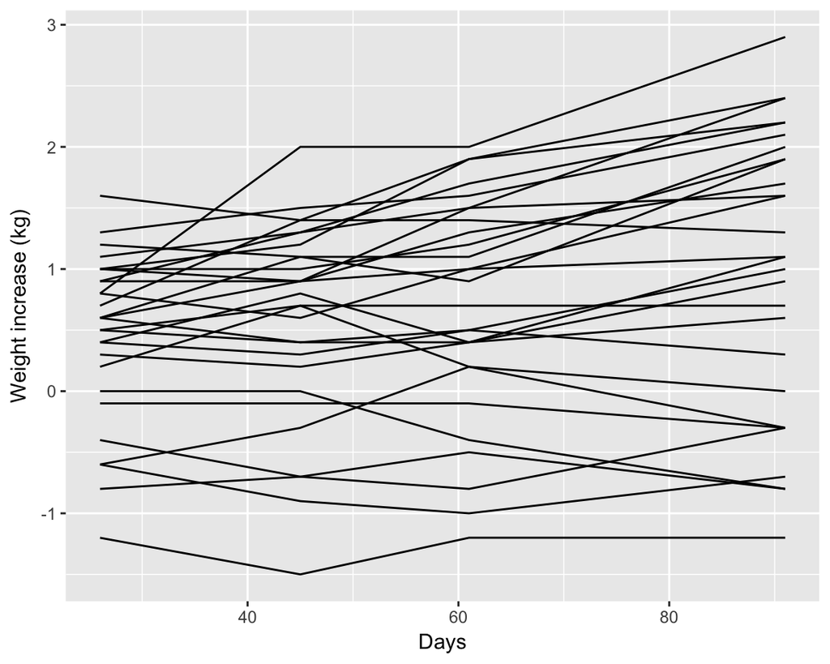

# Summary measure

Reducer de longitudinale målinger til et mål per individ (dvs kurve), der opsummerer noget relevant om hele kurveforløbet i lyset af den praktiske problemstilling.

Eksempler

- tilvækst over hele perioden
- relativ tilvækst over hele perioden
- arealet under kurven (evt blot over en del af det observerede tidsinterval)

Når de gentagne målinger er reduceret til et (relevant) “summary measure” for hvert individ, så kan man nå langt med klassiske variansanalysemodeller uden brug af tilfældige effekter.

Eksempel: tilvækst fra day = 0 til day = 91 (justeret for baselinevægt)

```r
goatdata91 <- subset(goatdata, day == 91)
head(goatdata91)
```

```
   goat feed   w0 day weight dayfac incr
5     1    1 20.4  91   22.3     91  1.9
10    2    1 10.3  91   12.5     91  2.2
15    3    1 12.5  91   15.4     91  2.9
20    4    1 10.8  91   12.5     91  1.7
25    5    1 13.6  91   15.8     91  2.2
30    6    1 19.0  91   19.6     91  0.6
```

```r
m0 <- lm(incr ~ factor(feed) + w0 ,goatdata91)
m1 <- lm(incr ~ 1 + w0 ,goatdata91)
anova(m1, m0)
```

```
Analysis of Variance Table

Model 1: incr ~ 1 + w0
Model 2: incr ~ factor(feed) + w0
  Res.Df    RSS Df Sum of Sq      F    Pr(>F)
1     26 36.527
2     23  8.465  3    28.062 25.416 1.746e-07 ***
---
Signif. codes:  0 '***' 0.001 '**' 0.01 '*' 0.05 '.' 0.1 ' ' 1
```

# Random intercept model

For at tage højde for, at der er afhængighed mellem målinger taget på samme individ (her: ged), så kan man udover effekten af de systematiske variable (**feed, day, w0**) tilføje et (tilfældigt) niveau (=Intercept) for hver ged.

Rent grafisk svarer det til, at man tillader en stokastisk individuel forskydning af kurverne, og modellen omtales ofte som *random intercept* modellen.

*Random intercept* modellen kan fittes med enten lme eller lmer.

```r
library(nlme)
modRI <- lme(weight ~ w0 + factor(feed) : factor(day) - 1, random = ~ 1 | goat
            , method = "REML", data = goatdata0)
modRI
```

```
Linear mixed-effects model fit by REML
  Data: goatdata0
  Log-restricted-likelihood: -52.81966
  Fixed: weight ~ w0 + factor(feed):factor(day) - 1
                         w0 factor(feed)1:factor(day)26
                  0.9416031                   1.5671917
factor(feed)2:factor(day)26 factor(feed)3:factor(day)26
                  1.2115047                   1.7253760
factor(feed)4:factor(day)26 factor(feed)1:factor(day)45
                  0.3301688                   1.9814774
factor(feed)2:factor(day)45 factor(feed)3:factor(day)45
                  1.1543619                   1.9110903
factor(feed)4:factor(day)45 factor(feed)1:factor(day)61
                  0.2444546                   2.0814774
factor(feed)2:factor(day)61 factor(feed)3:factor(day)61
                  1.4400761                   2.0968046
factor(feed)4:factor(day)61 factor(feed)1:factor(day)91
                  0.1587403                   2.5529060
factor(feed)2:factor(day)91 factor(feed)3:factor(day)91
                  1.6257904                   2.6539474
factor(feed)4:factor(day)91
                  0.1158831

Random effects:
 Formula: ~1 | goat
        (Intercept)  Residual
StdDev:   0.4119751 0.2568313

Number of Observations: 112
Number of Groups: 28
```

Som beskrevet på slides fra dagens forelæsning, så er det muligt at reducere lidt i middelværdistrukturen. Prøv selv at gøre dette (-søg eventuelt inspiration i eksemplet med Hydrolyse af fødevareprøver fra kursusuge 3).

# Digglemodellen

### Seriel korrelation inden for individ

Vi vælger at analysere data udgangspunkt i en statistisk model, hvor baselinevægten (w0) inddrages som en kovariat, og hvor vekselvirkningen mellem **feed** og **day** benyttes til at beskrive gennemsnitskurverne for de fire fodertyper.

Nedenfor estimeres parametrene i middelværdistrukturen ved brug af lm-funktionen i R. Formålet er at beregne den empiriske kovarians for residualerne med henblik på at finde en god model for kovariansstrukturen.

Datamanipulationerne vist her er ikke del af pensum!

```r
lmFit0 <- lm(weight ~ w0 + feed * dayfac, data = goatdata0)
res_data <- select(data.frame(goatdata0, res = resid(lmFit0)), goat, dayfac, res)%>%
  spread(key = dayfac, res)%>%
  select(-1)
head(res_data)
```

```
           26          45           61         91
1  0.22410568  0.30981996  0.009819964  0.5383914
2  0.13429668 -0.07998904  0.220010961  0.2485824
3 -0.03723008  0.74848421  0.648484209  1.0770556
4 -0.33650486 -0.45079057 -0.150790574 -0.2222191
5  0.82700655  0.21272083  0.612720833  0.4412923
6 -0.05765003 -0.07193574 -0.571935740 -0.8433643
```

Udregn kovarians og korrelation for residualer

```r
cov(res_data)
```

```
          26        45        61        91
26 0.1573632 0.1287074 0.1117758 0.1481151
45 0.1287074 0.1749722 0.1355009 0.1621048
61 0.1117758 0.1355009 0.1643894 0.1776070
91 0.1481151 0.1621048 0.1776070 0.3136818
```

```r
cor(res_data)
```

```
          26        45        61        91
26 1.0000000 0.7756528 0.6949591 0.6666579
45 0.7756528 1.0000000 0.7989522 0.6919371
61 0.6949591 0.7989522 1.0000000 0.7821293
91 0.6666579 0.6919371 0.7821293 1.0000000
```

Vi ser at afhængighedsstrukturen (=kovarians/korrelation) aftager med afstanden mellem måletidspunkterne.

Vi ønsker at finde en model, der fanger kovariansstrukturen bedre end *random intercept* modellen, der blot siger at kovariansen mellem målinger er ens (uanset afstand mellem måletidspunkter).

### Fit Diggle model i R

Diggle modellen tillader at kovariansen mellem to målinger på samme individ aftager med afstanden, $h$, mellem måletidspunkterne.

```r
head(goatdata0)
```

```
  goat feed   w0 day weight dayfac incr
1    1    1 20.4  26   21.0     26  0.6
2    1    1 20.4  45   21.5     45  1.1
3    1    1 20.4  61   21.3     61  0.9
4    1    1 20.4  91   22.3     91  1.9
5    2    1 10.3  26   11.4     26  1.1
6    2    1 10.3  45   11.6     45  1.3
```

```r
mGausNugget <- lme(weight ~ w0 + factor(feed) * factor(day), random = ~ 1 | goat, cor = corGaus(form = ~ day | goat, nugget = T), data = goatdata0)
getVarCov(mGausNugget, individuals = 1, type = "marginal")
```

```
goat 1
Marginal variance covariance matrix
        1       2       3       4
1 0.25133 0.20557 0.18354 0.16218
2 0.20557 0.25133 0.20937 0.17185
3 0.18354 0.20937 0.25133 0.19019
4 0.16218 0.17185 0.19019 0.25133
  Standard Deviations: 0.50133 0.50133 0.50133 0.50133
```

Diggle modellen kan også fittes uden nugget effekt

```r
mGausNoNugget <- lme(weight ~ w0 + factor(feed) * factor(day), random = ~ 1 | goat, cor = corGaus(form = ~ day | goat, nugget = F), data = goatdata0)
getVarCov(mGausNoNugget, individuals = 1, type = "marginal")
```

```
goat 1
Marginal variance covariance matrix
        1       2       3       4
1 0.24668 0.19724 0.17076 0.16803
2 0.19724 0.24668 0.20700 0.16826
3 0.17076 0.20700 0.24668 0.17469
4 0.16803 0.16826 0.17469 0.24668
  Standard Deviations: 0.49667 0.49667 0.49667 0.49667
```

### Modelreduktion

Tænk nøje over, hvilke modeller / hypoteser der testes neden for.

Husk at fitte modeller med **method = “ML”**!

```r
mod0 <- lme(weight ~ w0 + factor(feed) * factor(day), random = ~ 1 | goat
            , cor = corGaus(form = ~ day | goat, nugget = T)
            , method = "ML", data = goatdata0)
mod1 <- lme(weight ~ w0 + factor(feed) + factor(day), random = ~ 1 | goat
            , cor = corGaus(form = ~ day | goat, nugget = T)
            , method = "ML", data = goatdata0)
anova(mod1, mod0)
```

```
     Model df       AIC      BIC    logLik   Test L.Ratio p-value
mod1     1 12 114.67582 147.2978 -45.33791
mod0     2 21  96.85771 153.9462 -27.42886 1 vs 2 35.8181  <.0001
```

```r
mod2 <- lme(weight ~ w0 + factor(feed) * day, random = ~ 1 | goat
            , cor = corGaus(form = ~ day | goat, nugget = T)
            , method = "ML", data = goatdata0)
anova(mod2, mod0)
```

```
     Model df      AIC      BIC    logLik   Test  L.Ratio p-value
mod2     1 13 89.71611 125.0566 -31.85805
mod0     2 21 96.85771 153.9462 -27.42886 1 vs 2 8.858394  0.3544
```

```r
mod3 <- lme(weight ~ w0 + factor(feed) + day, random = ~ 1 | goat
            , cor = corGaus(form = ~ day | goat, nugget = T)
            , method = "ML", data = goatdata0)
anova(mod3, mod2)
```

```
     Model df       AIC      BIC    logLik   Test  L.Ratio p-value
mod3     1 10 111.58963 138.7746 -45.79482
mod2     2 13  89.71611 125.0566 -31.85805 1 vs 2 27.87353  <.0001
```

```r
anova(mod3, mod1)
```

```
     Model df      AIC      BIC    logLik   Test   L.Ratio p-value
mod3     1 10 111.5896 138.7746 -45.79482
mod1     2 12 114.6758 147.2978 -45.33791 1 vs 2 0.9138153  0.6332
```

```r
mod4 <- lme(weight ~ w0 + factor(feed) : day, random = ~ 1 | goat
            , cor = corGaus(form = ~ day | goat, nugget = T)
            , method = "ML", data = goatdata0)
anova(mod4, mod2)
```

```
     Model df      AIC      BIC    logLik   Test  L.Ratio p-value
mod4     1 10 94.44213 121.6271 -37.22106
mod2     2 13 89.71611 125.0566 -31.85805 1 vs 2 10.72602  0.0133
```

### Estimater

Estimater fra *mod2* (husk at refitte med **method = “REML”**).

Mere om fortolkning af parameterestimaterne: se slides fra dagens forelæsning!

```r
mod2refit <- lme(weight ~ w0 + factor(feed) + factor(feed) : day - 1, random = ~ 1 | goat
            , cor = corGaus(form = ~ day | goat, nugget = T)
            , method = "REML", data = goatdata0)
mod2refit
```

```
Linear mixed-effects model fit by REML
  Data: goatdata0
  Log-restricted-likelihood: -58.96689
  Fixed: weight ~ w0 + factor(feed) + factor(feed):day - 1
               w0     factor(feed)1     factor(feed)2     factor(feed)3
      0.943192548       1.182471409       0.979741484       1.298387951
    factor(feed)4 factor(feed)1:day factor(feed)2:day factor(feed)3:day
      0.385603258       0.014920931       0.006700554       0.014312541
factor(feed)4:day
     -0.003310775

Random effects:
 Formula: ~1 | goat
        (Intercept)  Residual
StdDev:   0.3962525 0.3069467

Correlation Structure: Gaussian spatial correlation
 Formula: ~day | goat
 Parameter estimate(s):
     range     nugget
41.0848916  0.3723881
Number of Observations: 112
Number of Groups: 28
```

### Semivariogram (kode)

Et semivariogram kan bruges til at opsummere:

- hvordan dissimilariteten mellem målinger på samme individ vokser med afstanden mellem målingerne
- om den observerede dissimilaritet (punkterne) kan approksimeres med den teoretiske dissimilaritet svarende til den estimerede model

En (eventuel) *Nugget*-effekt ses ved, at semivariogrammet *ikke* går gennem punktet (0,0).

```r
plot(Variogram(mod0), ylim = c(0, 1.2))
```

### Semivariogram

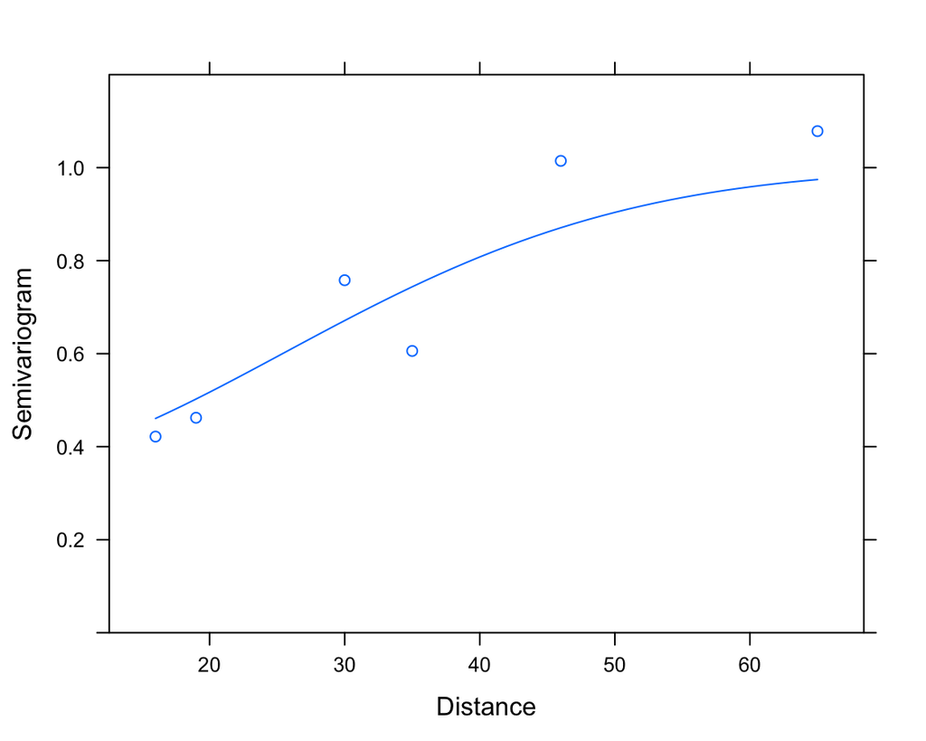

### Diggle vs. random intercept

En *random intercept* model siger at afhængigheden (og dermed dissimilariteten) mellem punkter taget på samme individ *ikke* afhænger af afstanden mellem måletidspunkterne.

En *random intercept* model vil derfor typisk passe godt, hvis punkterne på semivariogrammet ligger omkring en vandret linje (dvs. ingen voksende tendens).

En formel sammenligning kan foretages ved at vælge den model (Diggle eller Random Intercept), der har den laveste værdi af Akaike’s informationskriterie (AIC).

```r
modRI <- lme(weight ~ w0 + factor(feed) * factor(day), random = ~ 1 | goat
            , method = "REML", data = goatdata0)
modDiggle <- lme(weight ~ w0 + factor(feed) * factor(day)
                 , random = ~ 1 | goat
                 , corr = corGaus(form = ~ day | goat, nugget = T)
                 , method = "REML", data = goatdata0)

anova(modRI, modDiggle)
```

```
          Model df      AIC      BIC    logLik   Test  L.Ratio p-value
modRI         1 19 143.6393 192.1630 -52.81966
modDiggle     2 21 140.7827 194.4141 -49.39134 1 vs 2 6.856638  0.0324
```

AIC er mindst for Diggle modellen, så denne foretrækkes.

Begge værdier er taget fra modeller fittet med **method=“REML”**.

Når man benytter anova()-funktionen til at sammenligne korrelationsstrukturer ved at se på AIC-værdierne fra testtabellen, så betyder det ikke noget, om begge modeller er fittet med REML eller ML estimation (når blot middelværdistrukturen / den systematiske del af modellen er ens).

# Øvrige modeller med seriel korrelation

### Fri korrelationsstruktur

Bemærk, at variansen tvinges til at være ens til alle måletidspunkter

```r
mUnrestrictCor <- lme(weight ~ w0 + factor(feed) * factor(day),
                       random=~1|goat, cor = corSymm(form = ~ 1 |goat), data = goatdata0)
getVarCov(mUnrestrictCor,individuals=1,type="marginal")
```

```
goat 1
Marginal variance covariance matrix
        1       2       3       4
1 0.25542 0.21178 0.19504 0.16488
2 0.21178 0.25542 0.21572 0.17222
3 0.19504 0.21572 0.25542 0.18854
4 0.16488 0.17222 0.18854 0.25542
  Standard Deviations: 0.5054 0.5054 0.5054 0.5054
```

### Fri kovariansstruktur

Her estimeres både korrelationsmatrix og varianser til de forskellige tidspunkter helt frit. Dette svarer til, at der ikke er nogle restriktioner på kovariansmatricen.

```r
mUnrestrictCov <- lme(weight ~ w0 + factor(feed) * factor(day),
                       random = ~ 1 | goat, cor = corSymm(form = ~ 1 |goat),
                      weights = varIdent(form = ~ 1 | day),
                      data = goatdata0)
getVarCov(mUnrestrictCov,individuals=1,type="marginal")
```

```
goat 1
Marginal variance covariance matrix
        1       2       3       4
1 0.18409 0.15160 0.13208 0.17359
2 0.15160 0.20340 0.15852 0.18908
3 0.13208 0.15852 0.19054 0.20605
4 0.17359 0.18908 0.20605 0.35977
  Standard Deviations: 0.42906 0.451 0.43651 0.59981
```

### Diggle model uden random intercept

Kan fittes i R ved brug af *gls()*-funktionen

```r
mGausNoRI <- gls(weight ~ w0 + factor(feed) * factor(day), cor = corGaus(form = ~ day | goat, nugget = T), data = goatdata0)
getVarCov(mGausNoRI, individuals = 1, type = "marginal")
```

```
Marginal variance covariance matrix
        [,1]    [,2]    [,3]    [,4]
[1,] 0.24968 0.19872 0.18814 0.15558
[2,] 0.19872 0.24968 0.20004 0.17782
[3,] 0.18814 0.20004 0.24968 0.19205
[4,] 0.15558 0.17782 0.19205 0.24968
  Standard Deviations: 0.49967 0.49967 0.49967 0.49967
```

### Diggle model med variansinhomogenitet

```r
mGausNuggetInhom <- lme(weight ~ w0 + factor(feed) * factor(day), random = ~ 1 | goat, cor = corGaus(form = ~ day | goat, nugget = T)
                        , weights=varIdent(form=~1|day)
                        , data = goatdata0)
getVarCov(mGausNuggetInhom, individuals = 1, type = "marginal")
```

```
goat 1
Marginal variance covariance matrix
        1       2       3       4
1 0.20390 0.16851 0.15235 0.14053
2 0.16851 0.21455 0.16980 0.15037
3 0.15235 0.16980 0.19917 0.16533
4 0.14053 0.15037 0.16533 0.28658
  Standard Deviations: 0.45155 0.4632 0.44629 0.53533
```